# R语言与机器学习（上）

小天使格礼

在Rstudio中安装本节课所有需要的包，运行以下指令：

```r
install.packages(c(
  "dplyr", "tidyr", "data.table",
  "ggplot2", "patchwork", "RColorBrewer",
  "caret", "mlr3", "tidymodels",
  "MASS", "e1071", "class", "nnet",
  "rpart", "rpart.plot", "randomForest", "gbm", "xgboost",
  "pROC", "ROCR", "yardstick",
  "recipes", "dimRed", "RANN",
  "mlbench", "ISLR",
  "purrr", "broom", "knitr", "kableExtra"
))
```

# 目录

| 章节 | 主题 | 核心内容 |
| --- | --- | --- |
| 第一章 | 机器学习基础概念 | 定义、学习类型、问题类型、核心概念 |
| 第二章 | 数据预处理与特征工程 | 特征缩放、编码、缺失值、特征选择 |
| 第三章 | 模型评估与验证 | 评估指标、混淆矩阵、ROC曲线、交叉验证 |
| 第四章 | 线性模型 | 线性回归、逻辑回归、正则化、SVM |
| 第五章 | 树模型与集成学习 | 决策树、随机森林、GBDT、XGBoost |
| 第六章 | 支持向量机与核方法 | 最大间隔、核函数、核技巧、SVR |
| 第七章 | 最近邻与基于实例的方法 | KNN、距离度量、加权KNN |
| 第八章 | 贝叶斯与概率图模型 | 朴素贝叶斯、贝叶斯网络、高斯过程 |

# 第一章 机器学习基础概念

## 1.1 机器学习定义与核心思想

### 什么是机器学习？

**机器学习（Machine Learning）** 是人工智能的一个分支，其核心思想是让计算机从数据中”学习”规律，而不是由人类显式编程所有规则。

**经典定义**：

美国计算机科学家Tom Mitchell给出的定义：**“如果一个计算机程序在某类任务T上的性能P，随着经验E的积累而不断改善，则称该程序对任务T进行了学习。”**

这个定义包含三个核心要素：

1. **任务T（Task）**：程序要完成的工作，如分类、回归、聚类等
2. **性能P（Performance）**：衡量任务完成质量的指标，如准确率、均方误差等
3. **经验E（Experience）**：用于学习的数据，即训练样本

### 核心思想：从数据到决策

传统编程 vs 机器学习：

| 对比维度 | 传统编程 | 机器学习 |
| --- | --- | --- |
| 输入 | 数据 + 规则 | 数据 + 答案 |
| 输出 | 答案 | 规则（模型） |
| 核心逻辑 | 人类编写规则 | 算法自动学习规则 |
| 适用场景 | 规则明确、可穷举 | 规则复杂、难以显式表达 |

### 机器学习的本质

机器学习本质上是一个**函数逼近**问题：

$$\hat{f} \approx f$$

其中： - $f$：真实的数据生成函数（未知） - $\hat{f}$：学习到的模型（已知）

我们的目标是从假设空间中找到一个最优的 $\hat{f}$，使得它在未见数据上的表现尽可能好。

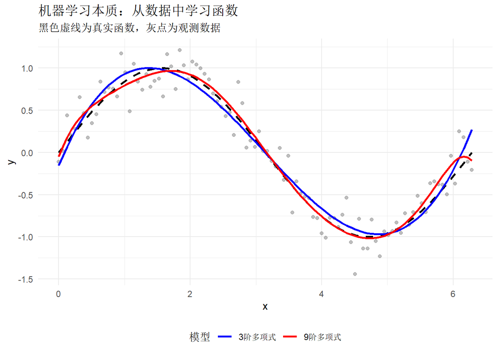

```r
# 机器学习本质示例：拟合一个未知函数
# 假设真实函数 f(x) = sin(x) + 噪声

# 生成模拟数据
set.seed(123)
n <- 100
x <- seq(0, 2 * pi, length.out = n)
y_true <- sin(x)  # 真实函数
y <- y_true + rnorm(n, mean = 0, sd = 0.2)  # 观测值（带噪声）

# 创建数据框
data <- data.frame(x = x, y = y, y_true = y_true)

# 用多项式回归"学习"这个函数
# 尝试不同阶数的多项式
model_3 <- lm(y ~ poly(x, degree = 3), data = data)
model_9 <- lm(y ~ poly(x, degree = 9), data = data)

# 预测
data$pred_3 <- predict(model_3)
data$pred_9 <- predict(model_9)

# 可视化：展示学习过程
ggplot2::ggplot(data, ggplot2::aes(x = x)) +
  ggplot2::geom_point(ggplot2::aes(y = y), alpha = 0.5, color = "gray50") +
  ggplot2::geom_line(ggplot2::aes(y = y_true), color = "black", linewidth = 1, linetype = "dashed") +
  ggplot2::geom_line(ggplot2::aes(y = pred_3, color = "3阶多项式"), linewidth = 1) +
  ggplot2::geom_line(ggplot2::aes(y = pred_9, color = "9阶多项式"), linewidth = 1) +
  ggplot2::scale_color_manual(values = c("3阶多项式" = "blue", "9阶多项式" = "red")) +
  ggplot2::labs(
    title = "机器学习本质：从数据中学习函数",
    subtitle = "黑色虚线为真实函数，灰点为观测数据",
    x = "x", y = "y", color = "模型"
  ) +
  ggplot2::theme_minimal() +
  ggplot2::theme(legend.position = "bottom")
```

### 意义与使用场景

**核心意义**：机器学习让计算机能够从数据中自动发现规律，解决那些规则复杂、难以显式编程的问题。

**举例**：基于患者的临床指标预测糖尿病风险

**为什么这种数据适合用机器学习？**

糖尿病的发生与年龄、BMI、血糖、血压、家族史等多种因素相关，这些因素之间存在复杂的交互作用和非线性关系，难以用简单的规则描述。机器学习可以从大量历史病例数据中自动学习这些复杂关系，建立预测模型。

**研究目的是什么？**

1. 风险评估：根据患者的各项指标，预测其患糖尿病的概率
2. 早期干预：识别高风险人群，进行针对性的预防措施
3. 辅助诊断：为临床医生提供决策支持

**可能得到什么样的结果？**

模型可能发现：年龄大于45岁、BMI超过28、空腹血糖高于6.1 mmol/L的患者，糖尿病风险显著升高。这些规律可能不是简单的线性组合，而是复杂的非线性关系。

**需要注意什么？**

机器学习模型是”黑箱”，其预测结果需要结合医学知识进行解释。同时，模型在训练数据上的表现好，不代表在新患者上也能准确预测，需要验证模型的泛化能力。

## 1.2 什么时候要用到机器学习

### 适用场景判断

机器学习并非万能，以下情况适合使用机器学习：

| 适用条件 | 说明 | 示例 |
| --- | --- | --- |
| 规则复杂 | 问题涉及大量变量和复杂关系 | 疾病诊断、股票预测 |
| 数据充足 | 有足够的历史数据用于学习 | 医疗影像、交易记录 |
| 模式存在 | 数据中确实存在可学习的规律 | 垃圾邮件识别 |
| 容忍误差 | 允许一定程度的预测错误 | 推荐系统 |
| 重复任务 | 需要对大量相似任务做决策 | 信用评分 |

### 不适合使用机器学习的场景

| 不适用条件 | 说明 | 替代方案 |
| --- | --- | --- |
| 规则简单明确 | 可以用简单的if-else解决 | 传统编程 |
| 数据不足 | 样本量太少无法学习 | 专家系统 |
| 需要完美准确 | 零容忍错误场景 | 规则引擎 |
| 需要完全解释 | 必须解释每个决策原因 | 统计模型 |
| 实时性要求极高 | 毫秒级响应要求 | 优化算法 |

### 意义与使用场景

**核心意义**：判断何时使用机器学习是项目成功的第一步，避免在不适合的场景浪费资源。

**举例**：医院是否需要用机器学习预测患者住院时长

**为什么需要先判断适用性？**

医院信息系统积累了大量患者数据，管理者想用机器学习预测住院时长以优化床位管理。但需要先评估：住院时长受病情、治疗方案、并发症等多种因素影响，规则复杂；历史数据充足（数万条记录）；确实存在可学习的规律（同类疾病住院时长有分布特征）；允许一定预测误差（用于规划而非精确安排）。这些条件都满足，适合使用机器学习。

**研究目的是什么？**

1. 床位规划：根据预测结果提前安排床位
2. 资源调配：预测高峰期，提前增加医护人员
3. 患者沟通：给患者提供大致住院时长预期

**可能得到什么样的结果？**

模型可能发现：年龄大于65岁、有并发症、手术类型为某类的患者，平均住院时长显著延长。预测准确率可能达到70-80%，足以支持规划决策。

**需要注意什么？**

如果数据质量差（缺失值多、记录不准），或预测精度要求极高（如ICU床位必须精确到天），则不适合使用机器学习，应考虑其他方案。

## 1.3 监督学习 vs 无监督学习 vs 半监督学习 vs 强化学习

### 四种主要学习范式

机器学习根据学习方式和数据特点，主要分为四种范式：

| 学习类型 | 是否有标签 | 数据特点 | 典型任务 |
| --- | --- | --- | --- |
| 监督学习 | 有 | 带标签的训练数据 | 分类、回归 |
| 无监督学习 | 无 | 无标签数据 | 聚类、降维 |
| 半监督学习 | 部分 | 少量标签+大量无标签 | 分类 |
| 强化学习 | 延迟奖励 | 环境交互反馈 | 决策控制 |

### 监督学习（Supervised Learning）

**定义**：从带标签的训练数据中学习一个映射函数，将输入映射到输出。

**数学表达**：

给定训练集 $D = \{(x_1, y_1), (x_2, y_2), ..., (x_n, y_n)\}$，学习函数 $f: X \rightarrow Y$，使得对新输入 $x_{new}$，能预测其输出 $y_{new}$。

**核心特点**： 1. 训练数据包含输入和对应的正确答案（标签） 2. 学习目标是建立输入到输出的映射关系 3. 可以用测试数据评估模型性能

```r
# 监督学习示例：鸢尾花分类
# 加载鸢尾花数据集
data(iris)

# 查看数据结构
head(iris)
```

```
##   Sepal.Length Sepal.Width Petal.Length Petal.Width Species
## 1          5.1         3.5          1.4         0.2  setosa
## 2          4.9         3.0          1.4         0.2  setosa
## 3          4.7         3.2          1.3         0.2  setosa
## 4          4.6         3.1          1.5         0.2  setosa
## 5          5.0         3.6          1.4         0.2  setosa
## 6          5.4         3.9          1.7         0.4  setosa
```

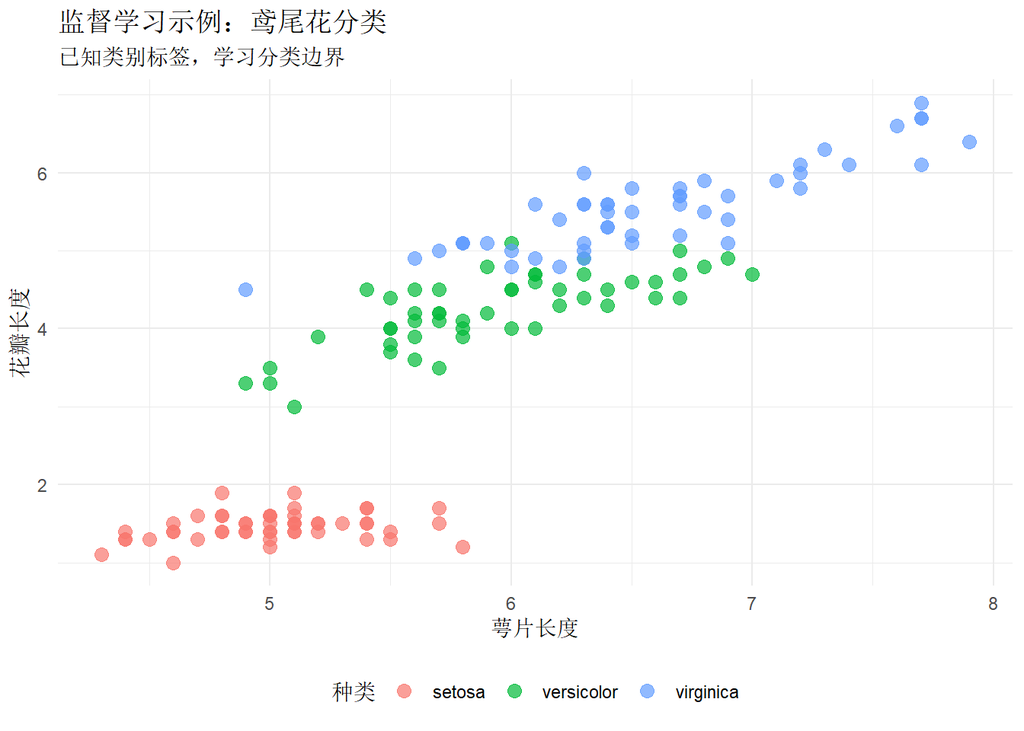

```r
# 可视化：不同种类的鸢尾花在特征空间中的分布
ggplot2::ggplot(iris, ggplot2::aes(x = Sepal.Length, y = Petal.Length, color = Species)) +
  ggplot2::geom_point(size = 3, alpha = 0.7) +
  ggplot2::labs(
    title = "监督学习示例：鸢尾花分类",
    subtitle = "已知类别标签，学习分类边界",
    x = "萼片长度", y = "花瓣长度", color = "种类"
  ) +
  ggplot2::theme_minimal() +
  ggplot2::theme(legend.position = "bottom")
```

### 无监督学习（Unsupervised Learning）

**定义**：从无标签数据中发现隐藏的结构或模式。

**数学表达**：

给定数据集 $D = \{x_1, x_2, ..., x_n\}$（无标签），发现数据的内在结构，如聚类或低维表示。

**核心特点**： 1. 训练数据没有标签 2. 学习目标是发现数据的内在结构 3. 评估标准不如监督学习明确

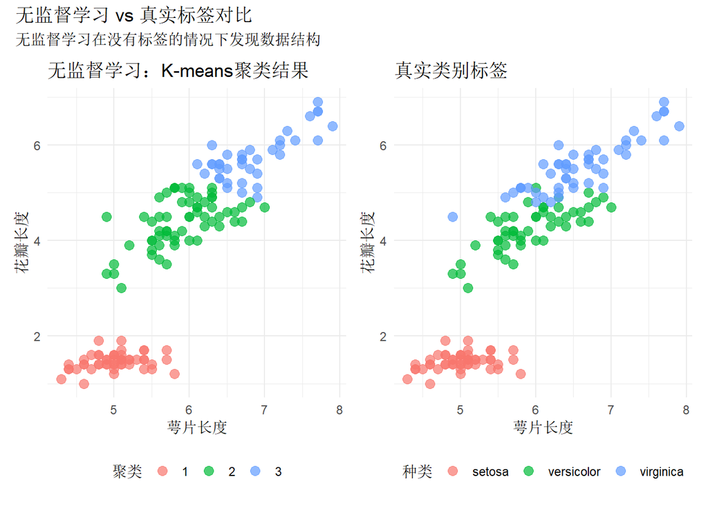

```r
# 无监督学习示例：K-means聚类
# 使用鸢尾花数据，但假装不知道真实类别

# 只取特征列（去掉标签）
iris_features <- iris[, 1:4]

# K-means聚类（假设不知道有3类）
set.seed(42)
kmeans_result <- kmeans(iris_features, centers = 3, nstart = 10)

# 将聚类结果添加到数据框
iris_clustered <- iris
iris_clustered$cluster <- as.factor(kmeans_result$cluster)

# 可视化：聚类结果 vs 真实类别
p1 <- ggplot2::ggplot(iris_clustered, ggplot2::aes(x = Sepal.Length, y = Petal.Length, color = cluster)) +
  ggplot2::geom_point(size = 3, alpha = 0.7) +
  ggplot2::labs(title = "无监督学习：K-means聚类结果", x = "萼片长度", y = "花瓣长度", color = "聚类") +
  ggplot2::theme_minimal() +
  ggplot2::theme(legend.position = "bottom")

p2 <- ggplot2::ggplot(iris, ggplot2::aes(x = Sepal.Length, y = Petal.Length, color = Species)) +
  ggplot2::geom_point(size = 3, alpha = 0.7) +
  ggplot2::labs(title = "真实类别标签", x = "萼片长度", y = "花瓣长度", color = "种类") +
  ggplot2::theme_minimal() +
  ggplot2::theme(legend.position = "bottom")

p1 + p2 + patchwork::plot_annotation(
  title = "无监督学习 vs 真实标签对比",
  subtitle = "无监督学习在没有标签的情况下发现数据结构"
)
```

### 半监督学习（Semi-supervised Learning）

**定义**：结合少量有标签数据和大量无标签数据进行学习。

**适用场景**： 1. 标签获取成本高（需要专家标注） 2. 无标签数据容易获取 3. 医学影像诊断（标注需要专业医生）

**核心思想**： 1. 利用有标签数据学习初步模型 2. 利用无标签数据增强模型（如伪标签、一致性正则化）

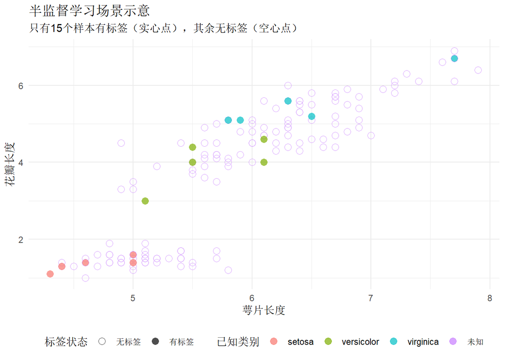

```r
# 半监督学习示意图
# 假设只有10%的数据有标签

set.seed(123)
n_labeled <- 15  # 只有15个样本有标签

# 随机选择有标签的样本
labeled_idx <- sample(1:nrow(iris), n_labeled)
iris_semi <- iris
iris_semi$label_status <- ifelse(1:nrow(iris) %in% labeled_idx, "有标签", "无标签")
iris_semi$known_species <- ifelse(1:nrow(iris) %in% labeled_idx, as.character(iris$Species), "未知")

# 可视化半监督学习场景
ggplot2::ggplot(iris_semi, ggplot2::aes(x = Sepal.Length, y = Petal.Length)) +
  ggplot2::geom_point(ggplot2::aes(color = known_species, shape = label_status), size = 3, alpha = 0.7) +
  ggplot2::scale_shape_manual(values = c("有标签" = 16, "无标签" = 1)) +
  ggplot2::labs(
    title = "半监督学习场景示意",
    subtitle = paste0("只有", n_labeled, "个样本有标签（实心点），其余无标签（空心点）"),
    x = "萼片长度", y = "花瓣长度", color = "已知类别", shape = "标签状态"
  ) +
  ggplot2::theme_minimal() +
  ggplot2::theme(legend.position = "bottom")
```

### 强化学习（Reinforcement Learning）

**定义**：智能体通过与环境交互，根据奖励/惩罚信号学习最优策略。

**核心要素**： 1. **智能体（Agent）**：学习者 2. **环境（Environment）**：智能体交互的对象 3. **动作（Action）**：智能体的行为 4. **状态（State）**：环境的当前情况 5. **奖励（Reward）**：环境对动作的反馈

**数学框架**：马尔可夫决策过程（MDP）

$$\text{目标：最大化累积奖励} \quad G_t =
\sum_{k=0}^{\infty} \gamma^k R_{t+k+1}$$

其中 $\gamma$ 是折扣因子，$0 \leq \gamma < 1$。

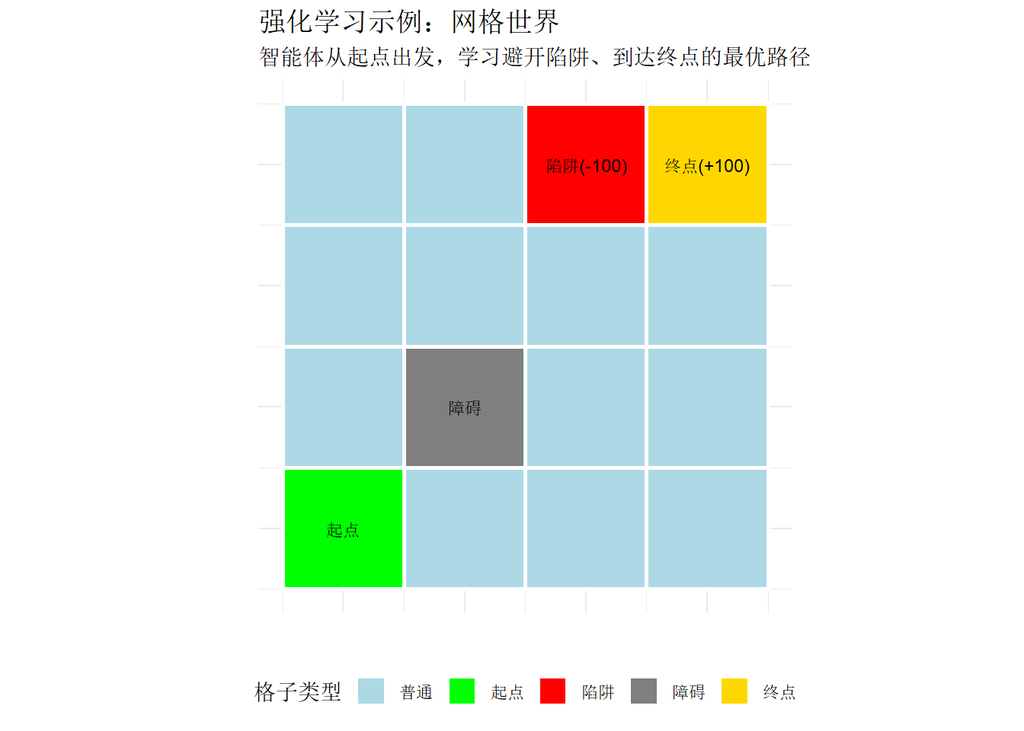

```r
# 强化学习概念示意图
# 创建一个简单的网格世界示例

grid_world <- data.frame(
  x = rep(1:4, each = 4),
  y = rep(1:4, 4),
  cell_type = c(
    "起点", "普通", "普通", "普通",
    "普通", "障碍", "普通", "普通",
    "普通", "普通", "普通", "陷阱",
    "普通", "普通", "普通", "终点"
  ),
  reward = c(
    0, -1, -1, -1,
    -1, NA, -1, -1,
    -1, -1, -1, -100,
    -1, -1, -1, 100
  )
)

# 添加标签
grid_world$label <- ifelse(is.na(grid_world$reward), "障碍",
                           ifelse(grid_world$reward == 100, "终点(+100)",
                                  ifelse(grid_world$reward == -100, "陷阱(-100)",
                                         ifelse(grid_world$reward == 0, "起点", ""))))

ggplot2::ggplot(grid_world, ggplot2::aes(x = x, y = y)) +
  ggplot2::geom_tile(ggplot2::aes(fill = cell_type), color = "white", linewidth = 1) +
  ggplot2::geom_text(ggplot2::aes(label = label), size = 3) +
  ggplot2::scale_fill_manual(values = c(
    "起点" = "green", "终点" = "gold", "障碍" = "gray50",
    "陷阱" = "red", "普通" = "lightblue"
  )) +
  ggplot2::labs(
    title = "强化学习示例：网格世界",
    subtitle = "智能体从起点出发，学习避开陷阱、到达终点的最优路径",
    x = "", y = "", fill = "格子类型"
  ) +
  ggplot2::theme_minimal() +
  ggplot2::theme(
    axis.text = ggplot2::element_blank(),
    axis.ticks = ggplot2::element_blank(),
    legend.position = "bottom"
  ) +
  ggplot2::coord_equal()
```

### 四种学习范式对比总结

| 学习类型 | 数据特点 | 学习目标 | 典型算法 | 医学应用 |
| --- | --- | --- | --- | --- |
| 监督学习 | 输入-标签对 | 预测标签 | 决策树、SVM、神经网络 | 疾病诊断、预后预测 |
| 无监督学习 | 无标签数据 | 发现结构 | K-means、PCA、自编码器 | 患者分型、基因聚类 |
| 半监督学习 | 少量标签+大量无标签 | 利用无标签数据提升性能 | 伪标签、一致性正则化 | 影像诊断（标注成本高） |
| 强化学习 | 环境交互反馈 | 学习最优策略 | Q-learning、Policy Gradient | 治疗方案优化 |

## 1.4 分类问题、回归问题、聚类问题

### 三大基本问题类型

机器学习任务根据输出类型的不同，主要分为三大类：

| 问题类型 | 输出类型 | 目标 | 典型算法 |
| --- | --- | --- | --- |
| 分类问题 | 离散类别 | 预测样本所属类别 | 逻辑回归、决策树、SVM |
| 回归问题 | 连续数值 | 预测连续值 | 线性回归、随机森林回归 |
| 聚类问题 | 无（发现结构） | 将相似样本分组 | K-means、层次聚类 |

### 分类问题（Classification）

**定义**：预测样本属于哪个离散类别。

**数学表达**：

给定输入 $x$，预测其类别 $y \in \{C_1, C_2, ..., C_K\}$

**分类类型**： 1. **二分类**：只有两个类别（如：患病/健康） 2. **多分类**：多个类别（如：肿瘤类型I/II/III期）

```r
# 分类问题示例：乳腺癌诊断
# 使用威斯康星乳腺癌数据集
data(BreastCancer, package = "mlbench")

# 数据预处理
bc_data <- BreastCancer %>%
  dplyr::select(-Id) %>%
  dplyr::mutate_all(~ifelse(. == "?", NA, .)) %>%
  tidyr::drop_na() %>%
  dplyr::mutate_at(vars(-Class), as.numeric)

# 查看数据
head(bc_data[, 1:5])
```

```
##   Cl.thickness Cell.size Cell.shape Marg.adhesion Epith.c.size
## 1            5         1          1             1            2
## 2            5         4          4             5            7
## 3            3         1          1             1            2
## 4            6         8          8             1            3
## 5            4         1          1             3            2
## 6            8        10         10             8            7
```

[figure not shown]

```r
# 可视化：两类样本在特征空间中的分布
ggplot2::ggplot(bc_data, ggplot2::aes(x = Cl.thickness, y = Cell.size, color = Class)) +
  ggplot2::geom_jitter(size = 2, alpha = 0.5, width = 0.2, height = 0.2) +
  ggplot2::labs(
    title = "分类问题示例：乳腺癌诊断",
    subtitle = "根据细胞特征预测良性/恶性",
    x = "细胞厚度", y = "细胞大小", color = "诊断结果"
  ) +
  ggplot2::theme_minimal() +
  ggplot2::theme(legend.position = "bottom")
```

### 回归问题（Regression）

**定义**：预测连续的数值输出。

**数学表达**：

给定输入 $x$，预测连续输出 $y \in \mathbb{R}$

**与分类的区别**： - 分类输出是离散的类别标签 - 回归输出是连续的数值

```r
# 回归问题示例：医疗费用预测
# 使用模拟数据演示

set.seed(456)
n_patients <- 200

# 生成模拟数据
medical_cost <- data.frame(
  age = round(runif(n_patients, 18, 80)),
  bmi = round(rnorm(n_patients, 25, 4), 1),
  smoker = sample(c("Yes", "No"), n_patients, replace = TRUE, prob = c(0.3, 0.7))
) %>%
  dplyr::mutate(
    # 医疗费用与年龄、BMI、吸烟状态相关
    cost = 1000 + 50 * age + 100 * bmi +
           ifelse(smoker == "Yes", 5000, 0) +
           rnorm(n_patients, 0, 1000)
  )

# 查看数据
head(medical_cost)
```

```
##   age  bmi smoker      cost
## 1  24 25.5     No  5467.349
## 2  31 28.5    Yes  9982.663
## 3  63 24.6     No  6578.476
## 4  71 25.3    Yes 11175.188
## 5  67 18.3     No  6179.478
## 6  39 29.5    Yes 12297.854
```

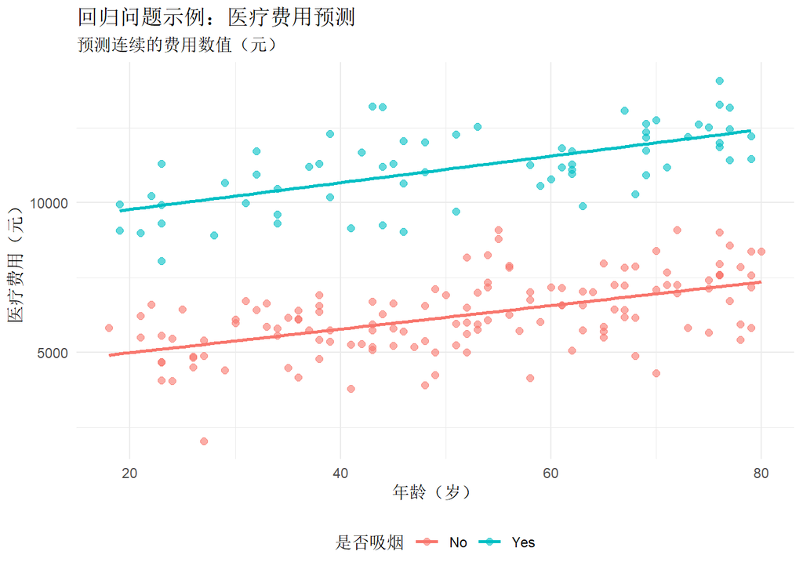

```r
# 可视化：费用与年龄的关系
ggplot2::ggplot(medical_cost, ggplot2::aes(x = age, y = cost, color = smoker)) +
  ggplot2::geom_point(size = 2, alpha = 0.6) +
  ggplot2::geom_smooth(method = "lm", se = FALSE) +
  ggplot2::labs(
    title = "回归问题示例：医疗费用预测",
    subtitle = "预测连续的费用数值（元）",
    x = "年龄（岁）", y = "医疗费用（元）", color = "是否吸烟"
  ) +
  ggplot2::theme_minimal() +
  ggplot2::theme(legend.position = "bottom")
```

### 聚类问题（Clustering）

**定义**：将相似的样本归为同一组，发现数据的内在结构。

**特点**： 1. 无监督学习（无标签） 2. 目标是发现数据的自然分组 3. “正确”的聚类结果可能不唯一

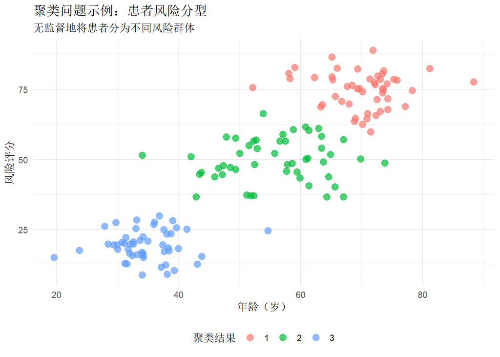

```r
# 聚类问题示例：患者分型
# 使用模拟数据演示

set.seed(789)
n_patients <- 150

# 生成三种不同类型的患者群体
patient_types <- data.frame(
  # 年轻低风险组
  age = c(rnorm(50, 35, 5), rnorm(50, 55, 8), rnorm(50, 70, 6)),
  risk_score = c(rnorm(50, 20, 5), rnorm(50, 50, 8), rnorm(50, 75, 7)),
  true_group = rep(c("低风险组", "中风险组", "高风险组"), each = 50)
)

# 进行K-means聚类（假装不知道真实分组）
kmeans_patients <- kmeans(patient_types[, c("age", "risk_score")], centers = 3, nstart = 10)
patient_types$cluster <- as.factor(kmeans_patients$cluster)

# 可视化聚类结果
ggplot2::ggplot(patient_types, ggplot2::aes(x = age, y = risk_score)) +
  ggplot2::geom_point(ggplot2::aes(color = cluster), size = 3, alpha = 0.7) +
  ggplot2::labs(
    title = "聚类问题示例：患者风险分型",
    subtitle = "无监督地将患者分为不同风险群体",
    x = "年龄（岁）", y = "风险评分", color = "聚类结果"
  ) +
  ggplot2::theme_minimal() +
  ggplot2::theme(legend.position = "bottom")
```

### 三种问题类型对比

| 问题类型 | 输出类型 | 目标 | 典型算法 | 评估指标 | 医学示例 |
| --- | --- | --- | --- | --- | --- |
| 分类问题 | 离散类别 | 预测样本所属类别 | 逻辑回归、决策树、SVM | 准确率、F1分数 | 疾病诊断、病理分型 |
| 回归问题 | 连续数值 | 预测连续值 | 线性回归、随机森林回归 | MSE、R² | 费用预测、生存时间预测 |
| 聚类问题 | 无（发现结构） | 将相似样本分组 | K-means、层次聚类 | 轮廓系数、SSE | 患者分型、基因表达聚类 |

### 意义与使用场景

**核心意义**：正确识别问题类型是选择合适算法的前提，不同问题类型对应不同的建模方法和评估指标。

**举例**：心血管疾病风险预测项目

**为什么需要区分问题类型？**

同一个医学问题可能被建模为不同类型：预测”是否患病”是分类问题，预测”患病概率”仍是分类（但输出概率），预测”生存年数”是回归问题，发现”患者亚群”是聚类问题。明确问题类型后才能选择正确的方法。

**研究目的是什么？**

1. 分类：判断患者是否属于高风险组，用于筛查决策
2. 回归：预测具体的风险评分或生存时间，用于个体化预后
3. 聚类：发现具有相似风险特征的患者亚群，用于精准医疗

**可能得到什么样的结果？**

分类模型可能输出”高风险/低风险”标签，准确率85%；回归模型可能输出”5年生存概率78%“，R²=0.65；聚类模型可能发现3个患者亚群，各有不同的预后特征。

**需要注意什么？**

有时问题类型可以相互转化：回归问题可以通过设置阈值转为分类问题；分类问题的概率输出可以用于排序。选择哪种类型取决于业务需求和数据特点。

## 1.5 特征（feature）与标签（label）

### 核心概念

在监督学习中，数据通常表示为**特征-标签**对：

| 概念 | 定义 | 符号表示 | 说明 |
| --- | --- | --- | --- |
| 特征 | 描述样本的属性 | $X$ 或 $x$ | 输入变量 |
| 标签 | 样本的目标值 | $y$ | 输出变量（监督学习特有） |

### 特征（Feature）

**定义**：描述样本的可测量属性或特性。

**特征类型**：

| 特征类型 | 数据类型 | 示例 | 编码方式 |
| --- | --- | --- | --- |
| 数值特征 | 连续/离散 | 年龄、血压 | 直接使用 |
| 类别特征 | 名义/有序 | 性别、疾病分期 | 独热编码/标签编码 |
| 文本特征 | 字符串 | 病历描述 | TF-IDF/词嵌入 |
| 图像特征 | 像素矩阵 | X光片 | CNN提取 |

```r
# 特征示例：心脏病预测数据集
# 创建模拟的心脏病预测数据

set.seed(111)
n <- 100

heart_data <- data.frame(
  # 数值特征
  age = round(runif(n, 30, 80)),                    # 年龄（连续）
  resting_bp = round(rnorm(n, 130, 20)),            # 静息血压（连续）
  cholesterol = round(rnorm(n, 200, 40)),           # 胆固醇（连续）
  max_heart_rate = round(220 - runif(n, 30, 80) + rnorm(n, 0, 10)),  # 最大心率

  # 类别特征
  sex = sample(c("Male", "Female"), n, replace = TRUE),           # 性别（名义）
  chest_pain = sample(c("Typical", "Atypical", "Non-anginal", "Asymptomatic"),
                      n, replace = TRUE),                          # 胸痛类型（名义）
  fasting_blood_sugar = sample(c(">120", "<=120"), n, replace = TRUE),  # 空腹血糖（二值）

  # 标签
  heart_disease = sample(c("Yes", "No"), n, replace = TRUE, prob = c(0.4, 0.6))
)

# 查看数据结构
head(heart_data)
```

```
##   age resting_bp cholesterol max_heart_rate    sex   chest_pain
## 1  60        134         196            183   Male Asymptomatic
## 2  66        161         125            153   Male  Non-anginal
## 3  49        148         173            147 Female      Typical
## 4  56        137         208            157   Male Asymptomatic
## 5  49        134          96            162   Male Asymptomatic
## 6  51        113         196            154 Female  Non-anginal
##   fasting_blood_sugar heart_disease
## 1                >120            No
## 2                >120            No
## 3                >120            No
## 4                >120           Yes
## 5                >120            No
## 6               <=120            No
```

```r
# 特征类型总结
```

| 特征名称 | 特征类型 | 数据类型 | 取值范围 |
| --- | --- | --- | --- |
| age | 数值-连续 | 整数 | 30-80岁 |
| resting_bp | 数值-连续 | 整数 | 约80-180 mmHg |
| cholesterol | 数值-连续 | 整数 | 约100-300 mg/dL |
| sex | 类别-名义 | 字符 | Male/Female |
| chest_pain | 类别-名义 | 字符 | 4种类型 |
| fasting_blood_sugar | 类别-二值 | 字符 | >120/<=120 |

### 标签（Label）

**定义**：监督学习中样本的目标值或正确答案。

**标签类型**：

| 任务类型 | 标签类型 | 示例 |
| --- | --- | --- |
| 二分类 | 二值 | 患病/健康 |
| 多分类 | 多个离散值 | 肿瘤I/II/III期 |
| 回归 | 连续数值 | 医疗费用、生存时间 |

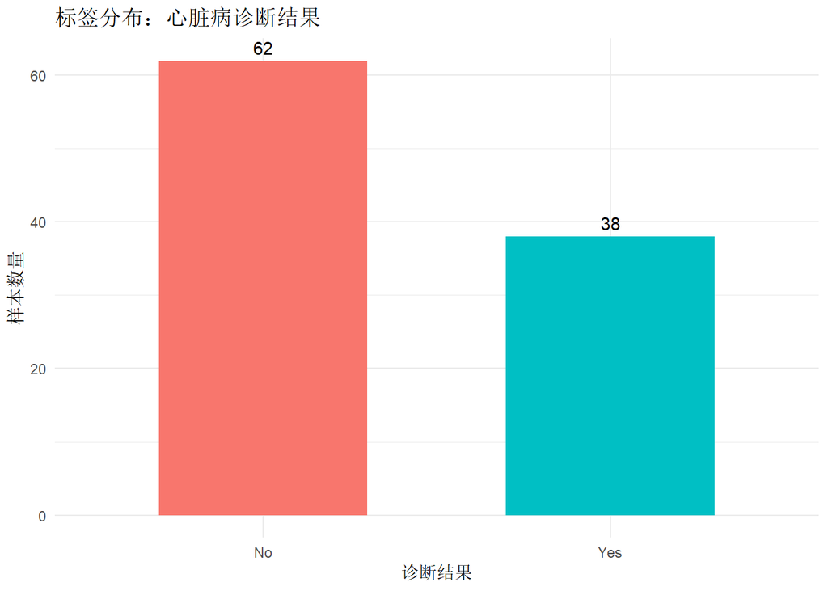

```r
# 标签分布可视化
ggplot2::ggplot(heart_data, ggplot2::aes(x = heart_disease, fill = heart_disease)) +
  ggplot2::geom_bar(width = 0.6) +
  ggplot2::geom_text(stat = "count", ggplot2::aes(label = after_stat(count)), vjust = -0.5) +
  ggplot2::labs(
    title = "标签分布：心脏病诊断结果",
    x = "诊断结果", y = "样本数量", fill = "诊断结果"
  ) +
  ggplot2::theme_minimal() +
  ggplot2::theme(legend.position = "none")
```

### 特征矩阵与标签向量

在机器学习中，数据通常表示为：

- **特征矩阵 $X$**：$n \times p$ 矩阵，$n$ 个样本，$p$ 个特征
- **标签向量 $y$**：$n \times 1$ 向量

$$X = \begin{bmatrix} x_{11} & x_{12}
& \cdots & x_{1p} \\ x_{21} & x_{22} & \cdots &
x_{2p} \\ \vdots & \vdots & \ddots & \vdots \\ x_{n1} &
x_{n2} & \cdots & x_{np} \end{bmatrix}, \quad y =
\begin{bmatrix} y_1 \\ y_2 \\ \vdots \\ y_n \end{bmatrix}$$

```r
# 特征矩阵与标签向量的表示
# 提取数值特征作为特征矩阵
X <- heart_data %>%
  dplyr::select(age, resting_bp, cholesterol, max_heart_rate) %>%
  as.matrix()

# 提取标签向量
y <- heart_data$heart_disease

# 显示维度
cat("特征矩阵 X 的维度：", dim(X), "\n")
```

```
## 特征矩阵 X 的维度： 100 4
```

```r
cat("  - 样本数量 n =", nrow(X), "\n")
```

```
##   - 样本数量 n = 100
```

```r
cat("  - 特征数量 p =", ncol(X), "\n")
```

```
##   - 特征数量 p = 4
```

```r
cat("\n标签向量 y 的长度：", length(y), "\n")
```

```
##
## 标签向量 y 的长度： 100
```

```r
cat("标签类别：", unique(y), "\n")
```

```
## 标签类别： No Yes
```

```r
# 特征矩阵前几行
cat("\n特征矩阵 X 前5行：\n")
```

```
##
## 特征矩阵 X 前5行：
```

```r
print(head(X, 5))
```

```
##      age resting_bp cholesterol max_heart_rate
## [1,]  60        134         196            183
## [2,]  66        161         125            153
## [3,]  49        148         173            147
## [4,]  56        137         208            157
## [5,]  49        134          96            162
```

### 意义与使用场景

**核心意义**：特征是机器学习模型的”原材料”，标签是监督学习的”答案”。特征的质量直接决定模型的上限。

**举例**：基于电子病历预测患者再入院风险

**为什么特征选择很重要？**

再入院风险受多种因素影响：年龄、诊断、用药、既往史、社会因素等。选择哪些作为特征，决定了模型能学到什么。如果遗漏重要特征（如既往再入院史），模型性能会受限；如果包含无关特征（如病历编号），可能引入噪声。

**研究目的是什么？**

1. 识别高风险患者：在出院前预测30天内再入院概率
2. 指导干预措施：对高风险患者进行重点随访
3. 资源配置：合理安排出院计划和随访资源

**可能得到什么样的结果？**

模型可能发现：年龄大于65岁、有多次既往住院史、出院时用药超过5种的患者，再入院风险显著升高。这些特征组合可以生成风险评分。

**需要注意什么？**

特征工程是机器学习中最耗时的环节之一。需要注意：1. 特征的完整性和准确性；2. 特征之间的相关性；3. 特征的可解释性；4. 避免数据泄露（如使用了未来信息）。

## 1.6 训练集、验证集、测试集划分

### 三种数据集的作用

在机器学习中，数据通常划分为三个独立的部分：

| 数据集 | 作用 | 比例建议 | 使用场景 |
| --- | --- | --- | --- |
| 训练集 | 训练模型参数 | 60-80% | 模型学习 |
| 验证集 | 调整超参数、模型选择 | 10-20% | 模型调优 |
| 测试集 | 评估最终性能 | 10-20% | 最终评估 |

### 为什么要划分？

**核心问题**：模型在训练数据上的表现好，不代表在新数据上也好。

**目标**：评估模型的**泛化能力**——在未见数据上的表现。

**三种数据集的分工**：

1. **训练集**：用于学习模型参数（如权重）
2. **验证集**：用于选择模型、调整超参数（如正则化系数）
3. **测试集**：最终评估，只能使用一次！

```r
# 数据划分示例
# 使用iris数据集演示

set.seed(42)

# 获取样本数量
n <- nrow(iris)

# 随机打乱样本顺序
indices <- sample(1:n)

# 计算划分点
train_end <- round(0.7 * n)
val_end <- round(0.85 * n)

# 划分数据集
train_idx <- indices[1:train_end]
val_idx <- indices[(train_end + 1):val_end]
test_idx <- indices[(val_end + 1):n]

# 创建三个数据集
train_data <- iris[train_idx, ]
val_data <- iris[val_idx, ]
test_data <- iris[test_idx, ]

# 显示划分结果
cat("训练集样本数:", nrow(train_data), "\n")
```

```
## 训练集样本数: 105
```

```r
cat("验证集样本数:", nrow(val_data), "\n")
```

```
## 验证集样本数: 23
```

```r
cat("测试集样本数:", nrow(test_data), "\n")
```

```
## 测试集样本数: 22
```

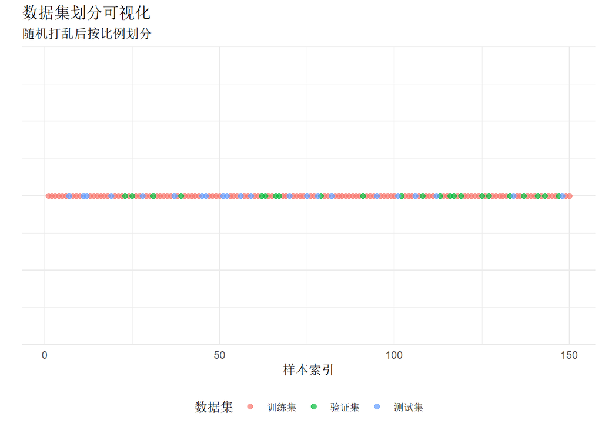

```r
# 可视化数据划分
split_viz <- data.frame(
  dataset = rep(c("训练集", "验证集", "测试集"),
                times = c(nrow(train_data), nrow(val_data), nrow(test_data))),
  index = c(train_idx, val_idx, test_idx)
)

split_viz$dataset <- factor(split_viz$dataset, levels = c("训练集", "验证集", "测试集"))

ggplot2::ggplot(split_viz, ggplot2::aes(x = index, y = 1, color = dataset)) +
  ggplot2::geom_point(size = 2, alpha = 0.7) +
  ggplot2::labs(
    title = "数据集划分可视化",
    subtitle = "随机打乱后按比例划分",
    x = "样本索引", y = "", color = "数据集"
  ) +
  ggplot2::theme_minimal() +
  ggplot2::theme(
    axis.text.y = ggplot2::element_blank(),
    axis.ticks.y = ggplot2::element_blank(),
    legend.position = "bottom"
  )
```

### 使用caret包进行数据划分

```r
# 使用caret包进行更规范的数据划分
library(caret)

# 创建训练集和测试集（70%-30%划分）
set.seed(42)
train_index <- caret::createDataPartition(iris$Species, p = 0.7, list = FALSE)

train_set <- iris[train_index, ]
test_set <- iris[-train_index, ]

# 在训练集内部再划分出验证集
set.seed(42)
val_index <- caret::createDataPartition(train_set$Species, p = 0.8, list = FALSE)

train_final <- train_set[val_index, ]
val_set <- train_set[-val_index, ]

# 显示最终划分
cat("训练集样本数:", nrow(train_final), "\n")
```

```
## 训练集样本数: 84
```

```r
cat("验证集样本数:", nrow(val_set), "\n")
```

```
## 验证集样本数: 21
```

```r
cat("测试集样本数:", nrow(test_set), "\n")
```

```
## 测试集样本数: 45
```

### 分层抽样

当类别不平衡时，需要使用**分层抽样**确保各数据集中类别比例一致。

```r
# 分层抽样示例
# 创建不平衡数据集

set.seed(123)
imbalanced_data <- data.frame(
  feature = rnorm(1000),
  label = c(rep("Positive", 100), rep("Negative", 900))  # 1:9不平衡
)

# 普通随机划分 vs 分层划分
set.seed(42)

# 普通随机划分
random_split <- sample(1:nrow(imbalanced_data), 0.7 * nrow(imbalanced_data))
train_random <- imbalanced_data[random_split, ]

# 分层划分（使用caret）
stratified_index <- caret::createDataPartition(imbalanced_data$label, p = 0.7, list = FALSE)
train_stratified <- imbalanced_data[stratified_index, ]

# 比较两种划分方式的类别比例
cat("原始数据Positive比例:", sum(imbalanced_data$label == "Positive") / nrow(imbalanced_data) * 100, "%\n")
```

```
## 原始数据Positive比例: 10 %
```

```r
cat("随机划分Positive比例:", sum(train_random$label == "Positive") / nrow(train_random) * 100, "%\n")
```

```
## 随机划分Positive比例: 10.14286 %
```

```r
cat("分层划分Positive比例:", sum(train_stratified$label == "Positive") / nrow(train_stratified) * 100, "%\n")
```

```
## 分层划分Positive比例: 10 %
```

### 意义与使用场景

**核心意义**：合理的数据划分是评估模型泛化能力的基础，避免”用考试题训练”的作弊行为。

**举例**：构建糖尿病预测模型

**为什么要划分三个数据集？**

假设我们有1000名患者的数据。如果全部用于训练，模型可能”记住”了这些患者的特征，在新患者上表现很差。划分后：700人用于训练，150人用于调参，150人用于最终测试。测试集的150人模拟”新患者”，评估模型的真实泛化能力。

**研究目的是什么？**

1. 训练集：让模型学习糖尿病的预测规律
2. 验证集：选择最佳模型参数（如决策树深度）
3. 测试集：报告模型的最终性能

**可能得到什么样的结果？**

训练集准确率85%，验证集准确率82%，测试集准确率80%。如果测试集准确率远低于训练集，说明模型过拟合，需要简化模型或增加数据。

**需要注意什么？**

1. 测试集只能使用一次，不能反复调整模型后再测试
2. 时间序列数据不能随机划分，要按时间顺序
3. 医学数据要考虑患者级别的划分（同一患者的数据不能同时出现在训练集和测试集）